# Movies

## Background

```r
movies31 <- read.csv("../Data/movies31.csv", header=TRUE,stringsAsFactors = FALSE)
CPI <- read.csv("../Data/CPI1914to2017.csv", header=TRUE, stringsAsFactors = FALSE)

movies31New<-merge(movies31,CPI, by.x = "year", by.y = "Year", all.x = TRUE)
movies31New$Budget2017<-movies31New$budget*movies31New$Factor
movies31New$Gross2017<-movies31New$gross*movies31New$Factor
movies31New$Profit2017<-movies31New$Gross2017-movies31New$Budget2017
#rownames(movies31New)<-movies31New$name
moviec<-c(1,10,8,3,4,9,6,2,7,19,20,21,11,14,12,5,13,15)
msort<-movies31New[moviec]
#table(msort$rating)
#b<-which(msort$rating == "R" | msort$rating == "PG" | msort$rating == "PG-13" | msort$rating == "G")
mr4<-subset(msort, rating %in% c("G","PG","PG-13","R"))
write.csv(mr4, file = "../Data/mr4.csv")
```

IMDB is an online database of information related to films and other entertainment[^1]. The movies dataset in this analysis is limited to movies within the following common MPAA ratings: “G”, “PG”, “PG-13”, and “R”.

**The question** I will be studying: How does the profit margin compare among the different MPAA rating groups?

This movie dataset can be downloaded here: [Movies (1986-2016)](https://webmailbyui-my.sharepoint.com/:x:/g/personal/harmkenn_byui_edu/EY_ZxGymiBJLr2iL1tbNu1IBVOYSVvwBEVQHNMuNTXYsKQ?e=jIdGXM)

## Analysis

I took the budget and gross sales of each movie and converted them into 2017 dollars for comparison[^2]. The difference between the gross sales and the budget is a good estimator of the profit margin for each movie.

Notice that a substantial number of movies lose money; at least 25% lose money in each rating category.

### Comparison of the Profit Margins by MPAA Rating

```r
attach(mr4)
pander::pander(favstats(Profit2017~rating, data = mr4))
```

Table continues below

| rating | min | Q1 | median | Q3 | max | mean |
| --- | --- | --- | --- | --- | --- | --- |
| G | -92520210 | -3794389 | 14833400 | 58953895 | 444714000 | 37257944 |
| PG | -139497807 | -5875370 | 9526770 | 39226942 | 528530675 | 24636806 |
| PG-13 | -189306433 | -13548712 | 4323315 | 33277484 | 712412092 | 18435857 |
| R | -187132618 | -6540799 | 691429 | 12124166 | 446425638 | 6759920 |

| sd | n | missing |
| --- | --- | --- |
| 80264853 | 147 | 0 |
| 6.7e+07 | 951 | 0 |
| 71043509 | 1995 | 0 |
| 38019018 | 3392 | 0 |

The summary statistics of each rating subgroup show that as the MPAA rating restriction increases, the profit margin tends to decrease.

### Graphical Comparison

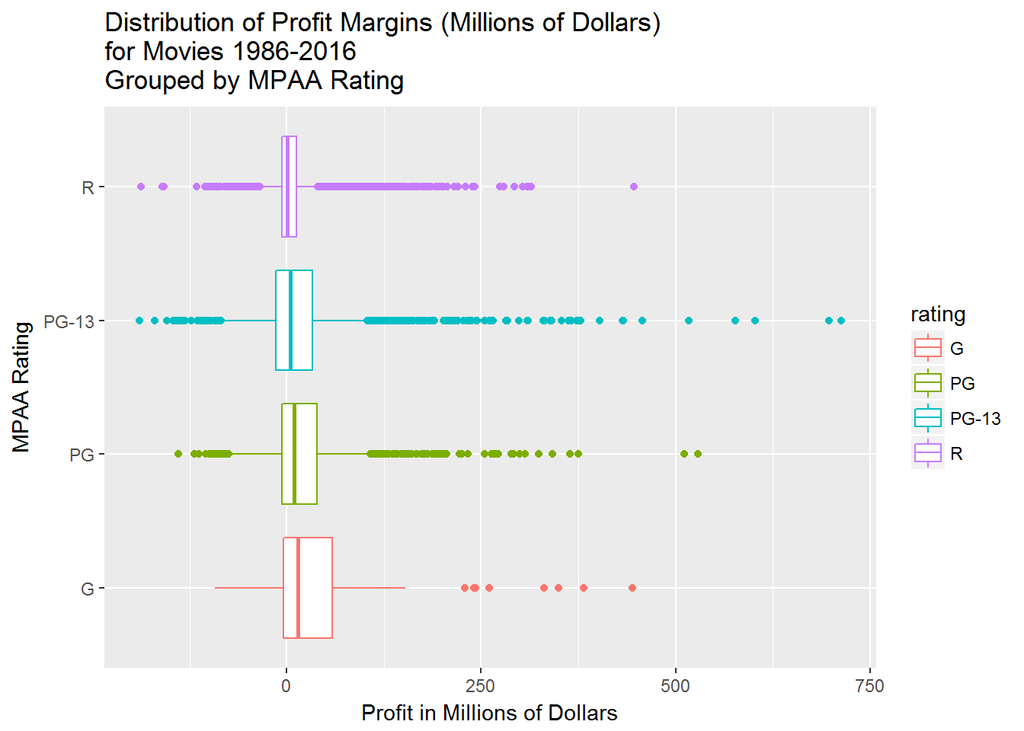

```r
ggplot(data = mr4, aes(x = rating, y = Profit2017/1000000)) + geom_boxplot()  + aes(colour = rating) + labs(title = "Distribution of Profit Margins (Millions of Dollars) \nfor Movies 1986-2016\nGrouped by MPAA Rating") + coord_flip() +labs(x="MPAA Rating", y="Profit in Millions of Dollars")
```

### Movie Popularity

The number of movies produced shows a reverse trend to the profit margins; as the MPAA restriction increases, the number of movies produced also increases.

#### Movies Produced

```r
pander::pander(table(mr4$rating))
```

| G | PG | PG-13 | R |
| --- | --- | --- | --- |
| 147 | 951 | 1995 | 3392 |

## Interpretation

It seems like if a less restricted movie is more profitable, then that would be the type of movie companies would want to produce. However, if you flood the market with G-rated movies, the distribution of profits would decrease; but it makes fiscal sense that the lower the rating, the greater the market.

[^1]: (Click on the link for details about the [IMDB movies dataset](https://www.kaggle.com/danielgrijalvas/movies/data).)
[^2]: Convert all budgets into 2017 dollars: [Relative Dollars](https://www.measuringworth.com/uscompare) & [CPI](https://www.saving.org/inflation/inflation.php?amount=100&year=1920)